# Module 5 Solutions

- Show All Code
- Hide All Code
- View Source

## Data set-up

See Module 1 Exercise Solutions for recommendations on how to import data.

The following packages were used for the solutions.

````markdown
```{r}
# Load libraries
library(tidyverse) # for data manipulation
library(skimr) # for skim() to summarise datasets
library(labelled) # for generate_dictionary() to view value labels
library(janitor) # for tabyl() to create frequency tables
library(lubridate) # for working with date variables
library(survival) # for survival analysis
library(broom) # to summarise model functions
#library(scales) # create better visualisations (check package installed, shouldn't need loading if ggplot2 is loaded)
library(ggplot2) # to create plots
library(comorbidity) # computing comorbidity indices
```
````

We import the data as provided in the Module 5 exercises.

1. Extract of first hospitalisation relating to cardivascular disease in our extended patient population

**Show R code**

```r
## Read in csv file
analysis_data_v2 <- read_csv("https://raw.githubusercontent.com/NicoleDeLaMata/LinkedData/refs/heads/main/analysis_data_v2.csv")
```

2. Additional data for the first hospitalisation relating to cardivascular disease in our extended patient population. This includes all the episodes of care relating to the entire index hospital admission for cardiovascular disease. There may be multiple rows per ppn for the same index hospital admission.

**Show R code**

```r
## Read in csv file
apdc_firstcvd <- read_csv("https://raw.githubusercontent.com/NicoleDeLaMata/LinkedData/refs/heads/main/apdc_firstcvd.csv")
```

3. All APDC episodes of care relating to extended patient population.

**Show R code**

```r
## Read in csv file
apdc_subset <- read_csv("https://raw.githubusercontent.com/NicoleDeLaMata/LinkedData/refs/heads/main/apdc_subset.csv")

## Convert date variables to date format then sort the data
apdc_subset <- apdc_subset %>%
  mutate(episode_start_date = dmy(episode_start_date),
         episode_end_date = dmy(episode_end_date)) %>%
  arrange(ppn, episode_start_date, episode_end_date)
```

4. Redacted and simplified mapping file of Statistical Area Codes 2016 to Australian Statistical Geography Standard (ASGS), Remoteness Area Structure 2016, accessible via [ABS](https://www.abs.gov.au/AUSSTATS/abs@.nsf/DetailsPage/1270.0.55.005July%202016?OpenDocument).

**Show R code**

```r
## Read in csv file
ra_sa2_mapping <- read_csv("https://raw.githubusercontent.com/NicoleDeLaMata/LinkedData/refs/heads/main/ra_sa2_mapping_2016.csv")
```

5. Redacted and simplified mapping file of Statistical Area Codes 2016 to Socio-Economic Indexes for Areas (SEIFA), Index of Relative Socio-economic Disadvantage 2016, accessible via [ABS](https://www.abs.gov.au/AUSSTATS/abs@.nsf/DetailsPage/2033.0.55.0012016?OpenDocument).

**NoteNote**

For the Index of Relative Socio-economic Disadvantage, decile one is interpreted as being most disadvantaged, and decile ten is least disadvantaged.

**Show R code**

```r
## Read in csv file
seifa_sa2_mapping <- read_csv("https://raw.githubusercontent.com/NicoleDeLaMata/LinkedData/refs/heads/main/seifa_sa2_mapping_2016.csv")
```

## AGE & SEX

## Question 1

Import and load the **apdc_firstcvd**. Determine the age and sex of each patient, reducing to one observation per ppn that was most frequently reported for the index hospital admission for cardiovascular disease.

**Show R code**

```r
# Retrieve age and sex from apdc_firstcvd
age_sex <- apdc_firstcvd %>% select(ppn, age_recode, sex)

# Count observations per person
age_sex <- age_sex %>% group_by(ppn) %>%
            mutate(rn = row_number()) %>%
            ungroup()

#Reshape to cross check discrepancies
age_sex_wide <- age_sex |> pivot_wider(
  id_cols=ppn,
  names_from = rn,
  values_from = c(age_recode, sex)
)

#Compare for discrepancies - for age
age_sex_wide %>% mutate(flag_age = case_when(
                        is.na(age_recode_2) ~ 0,
                        age_recode_1 != age_recode_2 & is.na(age_recode_3) ~ 1,
                        (age_recode_1 != age_recode_2 | age_recode_1 != age_recode_3) & is.na(age_recode_4) ~ 1,
                        (age_recode_1 != age_recode_2 | age_recode_1 != age_recode_3 | age_recode_1 != age_recode_4) & is.na(age_recode_5) ~ 1,
                        (age_recode_1 != age_recode_2 | age_recode_1 != age_recode_3 | age_recode_1 != age_recode_4 | age_recode_1 != age_recode_5) ~ 1,
                        TRUE ~ 0
                        )
                     ) %>%
  filter(flag_age==1) %>%  print()
```

```
# A tibble: 1 × 12
  ppn     age_recode_1 age_recode_2 age_recode_3 age_recode_4 age_recode_5 sex_1
  <chr>          <dbl>        <dbl>        <dbl>        <dbl>        <dbl> <dbl>
1 T1ckqS…           54           54           55           NA           NA     2
# ℹ 5 more variables: sex_2 <dbl>, sex_3 <dbl>, sex_4 <dbl>, sex_5 <dbl>,
#   flag_age <dbl>
```

**Show R code**

```r
#Compare for discrepancies - for sex
age_sex_wide %>% mutate(flag_sex = case_when(
                        is.na(sex_2) ~ 0,
                        sex_1 != sex_2 & is.na(sex_3) ~ 1,
                        (sex_1 != sex_2 | sex_1 != sex_3) & is.na(sex_4) ~ 1,
                        (sex_1 != sex_2 | sex_1 != sex_3 | sex_1 != sex_4) & is.na(sex_5) ~ 1,
                        (sex_1 != sex_2 | sex_1 != sex_3 | sex_1 != sex_4 | sex_1 != sex_5) ~ 1,
                        TRUE ~ 0
                        )
                     ) %>%
  filter(flag_sex==1) %>%  print()
```

```
# A tibble: 0 × 12
# ℹ 12 variables: ppn <chr>, age_recode_1 <dbl>, age_recode_2 <dbl>,
#   age_recode_3 <dbl>, age_recode_4 <dbl>, age_recode_5 <dbl>, sex_1 <dbl>,
#   sex_2 <dbl>, sex_3 <dbl>, sex_4 <dbl>, sex_5 <dbl>, flag_sex <dbl>
```

There is only one discrepancy for age and none for sex. Looking at PPN “T1ckqS0bQ2Q”, there were two occurrence of age 54 and one occurrence of age 55. This is plausible to have occurred if the patient had their birthday during their hospital admission. Regardless, we will take the most frequently reported value of age 54.

**Show R code**

```r
# Reduce age and sex to one value per ppn
age_sex_ppn <- age_sex_wide %>% select(ppn, age_recode = age_recode_1, sex = sex_1)
```

Merge the age and sex with the **analysis_data_v2** and complete the following:

**Show R code**

```r
#Merge into analysis data
analysis_data_v2 <- analysis_data_v2 %>% left_join(age_sex_ppn, by = "ppn")
```

1. Examine the distribution of the continuous numeric variable *age_recode*.

**Show R code**

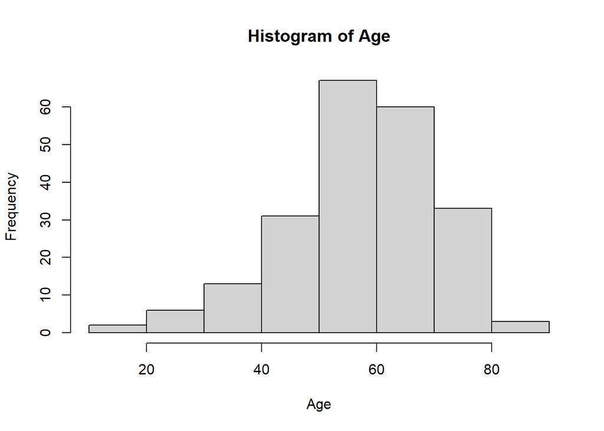

```r
# Distribution of age_recode
## Quick histogram for checking
analysis_data_v2 %>%
  pull(age_recode) %>%
  hist(main = "Histogram of Age",
    xlab = "Age")
```

**Show R code**

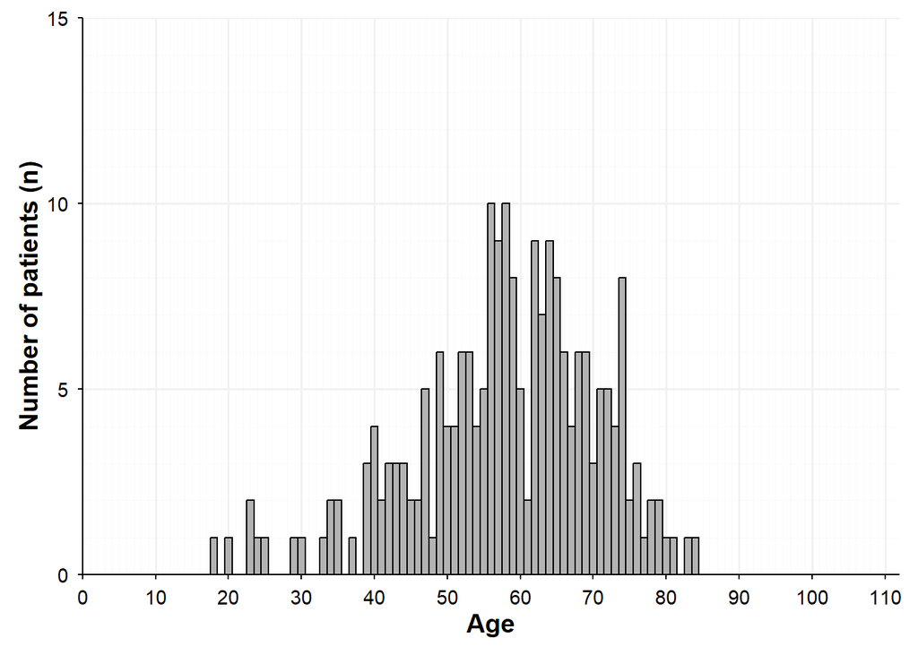

```r
## Nicer looking histogram
ggplot(data = analysis_data_v2, mapping = aes(x = age_recode)) +
  geom_histogram(binwidth = 1, colour = "black", fill = "grey70") +
  xlab("Age") +
  ylab("Number of patients (n)") +
  coord_cartesian(xlim = c(0, 112),
                  ylim = c(0, 15)) +
  scale_x_continuous(breaks = seq(0, 110, 10),
                     minor_breaks = seq(0, 110, 1),
                     expand = c(0, 0)) +
  scale_y_continuous(breaks = seq(0, 15, 5),
                     labels = scales::label_comma(),
                     minor_breaks = seq(0, 15, 1),
                     expand = c(0, 0)) +
  theme_minimal() +
  theme(axis.text = element_text(colour = "black", size = 11),
        axis.title = element_text(colour = "black", size = 14, face = "bold"),
        axis.line = element_line(colour = "black"),
        axis.ticks = element_line(colour = "black"),
        legend.position = "none",
        panel.grid.major = element_line(colour = "grey95", linewidth = 0.7),
        panel.grid.minor = element_line(colour = "grey98", linewidth = 0.2),
        panel.border = element_blank(),
        plot.margin = margin(t = 10, b = 10, l = 10, r = 10))
```

2. Create a new variable *agecat* that categorises *age_recode* into the following categories: <50, 50 to 59, 60 to 69, 70+

**Show R code**

```r
# Create age categories
analysis_data_v2 <- analysis_data_v2 %>%
  mutate(agecat = factor(
    case_when(
      age_recode < 50 ~ "<50",
      age_recode < 60 ~ "50-59",
      age_recode < 70 ~ "60-69",
      TRUE ~ "70+"),
    levels = c("<50", "50-59", "60-69", "70+")))

# frequency table of agecat
analysis_data_v2 %>%
  tabyl(agecat)
```

```
 agecat  n   percent
    <50 48 0.2232558
  50-59 66 0.3069767
  60-69 62 0.2883721
    70+ 39 0.1813953
```

3. Ensure *sex* is correctly formatted and tabulate the frequency distribution.

**Show R code**

```r
# Convert sex to a factor
analysis_data_v2 <- analysis_data_v2 %>%
  mutate(sex = factor(
    case_when(
      sex == "1" ~ "Male",
      sex == "2" ~ "Female"),
    levels = c("Female", "Male")))

# Frequency table of sex
analysis_data_v2 %>% tabyl(sex)
```

```
    sex   n   percent
 Female  83 0.3860465
   Male 132 0.6139535
```

## REMOTENESS & SOCIOECONOMIC STATUS

## Question 2

Using **apdc_firstcvd**, determine the SA2 code (*sa2_2016_code*) assigned to the first episode of care for each ppn. Reduce SA2 code to one observation per ppn for their the index hospital admission for cardiovascular disease.

**Show R code**

```r
# Reduce sa2_2016 to one value per ppn - most amount of days
sa2_code <- apdc_firstcvd %>%
                    arrange(ppn, episode_start_date) %>%
                    group_by(ppn) %>%
                    slice(1) %>%
                    ungroup() %>%
                    select(ppn, sa2_2016_code)

# Merge into the analysis data
analysis_data_v2 <- analysis_data_v2 %>% left_join(sa2_code, by = "ppn")
```

Merge the SA2 code with the **analysis_data_v2**, and subsequently:

1. Check **ra_sa2_mapping** to ensure it is one row per *sa2_2016*. If not, take a conservative approach and assume the location is more remote for duplicated rows (e.g. if one SA2 has both “inner regional” and “outer regional”, than assume “outer regional”). Once reduced to one observation per SA2, merge the remoteness area by SA2 code into your **analysis_data_v2**. Tabulate the remoteness area, *ra_2016*.

**Show R code**

```r
# Check for duplicates
ra_sa2_mapping %>% distinct(sa2_2016)
```

```
# A tibble: 576 × 1
    sa2_2016
       <dbl>
 1 101021007
 2 101021008
 3 101021009
 4 101021010
 5 101021011
 6 101021012
 7 101031013
 8 101031014
 9 101031015
10 101031016
# ℹ 566 more rows
```

The **ra_sa2_mapping** observations have reduced from 671 to 576, so duplicates of *sa2_2016* are definitely present.

**Show R code**

```r
# Reduce to one row per SA2
ra_sa2_mapping_one <- ra_sa2_mapping %>%
    mutate(ord = case_when(
      ra_2016 == "Very Remote Australia" ~ 1,
      ra_2016 == "Remote Australia" ~ 2,
      ra_2016 == "Outer Regional Australia" ~ 3,
      ra_2016 == "Inner Regional Australia" ~ 4,
      TRUE ~ 5
    )) %>%
  arrange(sa2_2016, ord) %>%
  group_by(sa2_2016) %>%
  slice(1) %>%
  ungroup() %>%
  select(-ord)

# Merge in the remoteness
analysis_data_v2 <- analysis_data_v2 %>% left_join(ra_sa2_mapping_one, join_by(sa2_2016_code == sa2_2016), relationship = "many-to-one")

# Frequency table of remoteness
analysis_data_v2 %>% tabyl(ra_2016)
```

```
                   ra_2016   n     percent
  Inner Regional Australia  44 0.204651163
 Major Cities of Australia 159 0.739534884
  Outer Regional Australia  10 0.046511628
          Remote Australia   1 0.004651163
     Very Remote Australia   1 0.004651163
```

2. Check **seifa_sa2_mapping** to ensure it is one row per *sa2_2016*. If not, take a conservative approach and assume the lowest score for duplicated rows. Once reduced to one observation per SA2, merge the SEIFA by SA2 code into your **analysis_data_v2**. Tabulate the SEIFA deciles, *seifa_irsd_decile*.

**Show R code**

```r
# Check for duplicates
seifa_sa2_mapping %>% distinct(sa2_2016)
```

```
# A tibble: 2,184 × 1
    sa2_2016
       <dbl>
 1 101021007
 2 101021008
 3 101021009
 4 101021010
 5 101021011
 6 101021012
 7 101031013
 8 101031014
 9 101031015
10 101031016
# ℹ 2,174 more rows
```

There are no duplicated rows as the **seifa_sa2_mapping** observations remained the same at 2,184.

**Show R code**

```r
# Merge in the SEIFA
analysis_data_v2 <- analysis_data_v2 %>% left_join(seifa_sa2_mapping, join_by(sa2_2016_code == sa2_2016), relationship = "many-to-one")

# Frequency table of SEIFA deciles
analysis_data_v2 %>% tabyl(seifa_irsd_decile)
```

```
 seifa_irsd_decile  n    percent valid_percent
                 1 21 0.09767442    0.09905660
                 2 15 0.06976744    0.07075472
                 3 17 0.07906977    0.08018868
                 4 31 0.14418605    0.14622642
                 5 17 0.07906977    0.08018868
                 6 23 0.10697674    0.10849057
                 7 16 0.07441860    0.07547170
                 8 19 0.08837209    0.08962264
                 9 10 0.04651163    0.04716981
                10 43 0.20000000    0.20283019
                NA  3 0.01395349            NA
```

## DIABETES & COMORBIDITY

## Question 3

Using the **apdc_subset**, we will calculate a Charlson comorbidity index (CCI) for each patient with a 1 year lookback period. Complete the following to create a dataset with one row per patient and their corresponding CCI. This will also be used to derive whether they have diabetes and diabetes complications.

1. Create a new dataset, **apdc_subset_com**, that restricts the dataset to the index hospital admission and any episodes of care within 1 year prior to the index hospital admission for cardiovascular disease.

**Show R code**

```r
# Episodes of care for index hospitalisations & 1 year prior
apdc_subset_com <- analysis_data_v2 %>%
            select(ppn, sepdate_last) %>%
            right_join(apdc_subset, by = "ppn") %>%
            filter((sepdate_last-episode_end_date)>=0 & (sepdate_last-episode_end_date)<=365.25)
```

2. Create new variables for each of the comorbid condition that flag whether that condition was ever recorded during each episode of care.

We will be using the *charlson()* function, so we need to add decimals to the diagnosis code variables.

**Show R code**

```r
## Load charlson package
library(devtools)
install_github("james-hedley/charlson")
library(charlson)

# Charlson package codings
comorbidity::available_algorithms()
```

```
Supported comorbidity mapping algorithms:
    * charlson_icd9_quan
    * charlson_icd10_quan
    * charlson_icd10_se
    * charlson_icd10_am
    * charlson_icd10_am_ucodes
    * elixhauser_icd9_quan
    * elixhauser_icd10_quan

Supported scoring weights algorithms:
    * For charlson_icd9_quan: charlson, quan
    * For charlson_icd10_quan: charlson, quan
    * For charlson_icd10_se: charlson, quan
    * For charlson_icd10_am: charlson, quan
    * For charlson_icd10_am_ucodes: charlson, quan
    * For elixhauser_icd9_quan: vw, swiss
    * For elixhauser_icd10_quan: vw, swiss
```

**Show R code**

```r
# Add decimal to diagnosis variables
dcodes <- c(paste0('diagnosis_code',c('P',seq(1:19))))

for (v in dcodes) {
  apdc_subset_com[[v]] <- ifelse(
    is.na(apdc_subset_com[[v]]),
    NA,
    paste0(substr(apdc_subset_com[[v]], 1, 3), ".", substr(apdc_subset_com[[v]], 4, nchar(apdc_subset_com[[v]])))
  )
}

# Create cogrp based on each episode of care (to create separate flags for each condition)
apdc_subset_com <- apdc_subset_com %>%
  charlson(newvar = cogrp,
           diagnosis_code_vars = paste0('diagnosis_code',c('P',seq(1:19))))
```

3. Collate the multiple lines per ppn for the comorbid conditions across the episodes of care, into one line per ppn.

**Show R code**

```r
# Update flags if patient has record of condition during index admission or previous 12 months
flag_vars <- c("ami", "chf", "pvd", "cva", "dementia", "pulmonary_disease",
               "ctd", "peptic_ulcer", "liver_disease", "diabetes",
               "diabetes_complications", "paraplegia", "renal_disease",
               "cancer", "metastatic_cancer", "severe_liver_disease", "hiv")

#Create comorbidity flags
apdc_subset_com <- apdc_subset_com %>%
  group_by(ppn) %>%
  mutate(across(all_of(flag_vars), ~ max(replace_na(.x, 0)))) %>%
  ungroup()
```

4. Calculate the CCI manually and name the variable *cogrp*. We would like you to exclude the following comorbidities from your CCI: any cardiovascular comorbidities (including myocardial infarction *mi*, congestive heart failure *chf*, peripheral vascular disease *pvd*, cerebral vascular accident *cva*), renal disease *rend* and, diabetes *diab* and diabetes complications *diabwc* (for further evaluation) from the final calculation. Merge this into your analysis dataset, **analysis_data_v2**.

**Show R code**

```r
# Manually calculate Charlson comorbidity index for each patient
apdc_subset_com <- apdc_subset_com %>%
  mutate(cogrp =
           ami * 0 + #Exclude myocardiacl infarction
           chf * 0 + #Exclude congestive heart failure
           pvd * 0 + #Exclude peripheral vascular disease
           cva * 0 + #Exclude cerebral vascular accident
           dementia * 1 +
           pulmonary_disease * 1 +
           ctd * 1 +
           peptic_ulcer * 1 +
           liver_disease * 1 +
           diabetes * 0 + # Exclude diabetes
           diabetes_complications * 0 + # Exclude diabetes complications
           paraplegia * 2 +
           renal_disease * 0 + # Exclude renal disease
           cancer * 2 +
           metastatic_cancer * 6 +
           severe_liver_disease * 3 +
           hiv * 6)

# Add cogrp back to analysis dataset
analysis_data_v2 <- apdc_subset_com %>%
          select(ppn, cogrp) %>%
          distinct() %>%
          right_join(analysis_data_v2, by = "ppn")
```

5. Examine the frequency distribution of *cogrp*.

**Show R code**

```r
# Examine distribution of cogrp
analysis_data_v2 %>%
  tabyl(cogrp)
```

```
 cogrp   n     percent
     0 211 0.981395349
     1   2 0.009302326
     3   2 0.009302326
```

**Show R code**

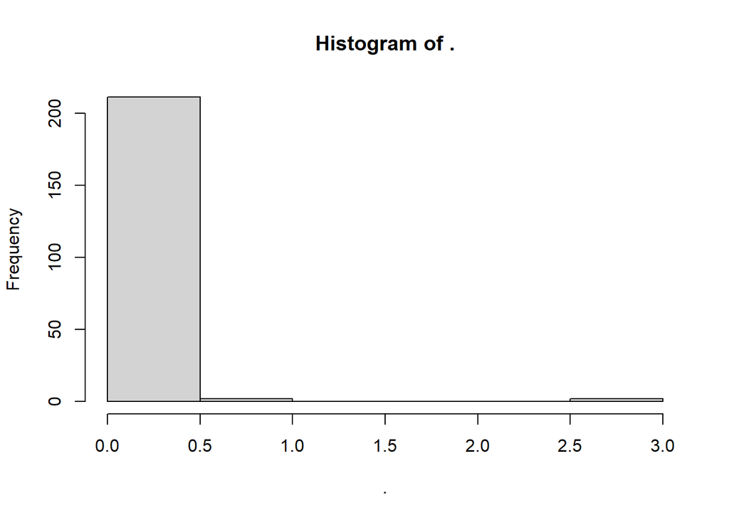

```r
## Quick histogram
analysis_data_v2 %>%
  pull(cogrp) %>%
  hist()
```

**Show R code**

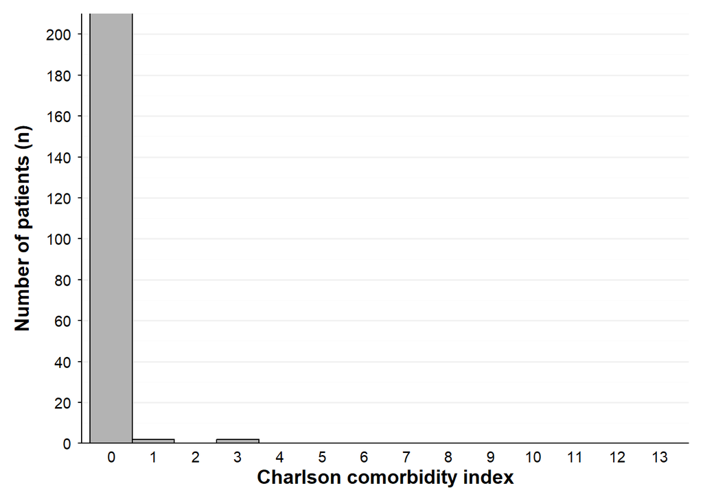

```r
## Nicer looking histogram
ggplot(data = analysis_data_v2, mapping = aes(x = cogrp)) +
  geom_histogram(binwidth = 1, colour = "black", fill = "grey70") +
  xlab("Charlson comorbidity index") +
  ylab("Number of patients (n)") +
  coord_cartesian(xlim = c(0, 13),
                  ylim = c(0, 210)) +
  scale_x_continuous(breaks = seq(0, 13, 1),
                     expand = c(0.05, 0.05)) +
  scale_y_continuous(breaks = seq(0, 210, 20),
                     labels = scales::label_comma(),
                     minor_breaks = seq(0, 210, 10),
                     expand = c(0, 0)) +
  theme_minimal() +
  theme(axis.text = element_text(colour = "black", size = 11),
        axis.title.y = element_text(colour = "black", size = 14, face = "bold",
                                  margin = margin(r = 10)),
        axis.title.x = element_text(colour = "black", size = 14, face = "bold"),
        axis.line = element_line(colour = "black"),
        axis.ticks.y = element_line(colour = "black"),
        axis.ticks.x = element_blank(),
        legend.position = "none",
        panel.grid.major.y = element_line(colour = "grey95", linewidth = 0.7),
        panel.grid.minor.y = element_line(colour = "grey98", linewidth = 0.2),
        panel.grid.major.x = element_blank(),
        panel.grid.minor.x = element_blank(),
        panel.border = element_blank(),
        plot.margin = margin(t = 10, b = 10, l = 10, r = 10))
```

6. Convert *cogrp* to a categorical variable with categories: 0, 1, 2 and 3+ and tabulate this variable.

**Show R code**

```r
# Create categorical version of cogrp
analysis_data_v2 <- analysis_data_v2 %>%
  mutate(cogrp = factor(
    case_when(
      cogrp == 0 ~ "0",
      cogrp == 1 ~ "1",
      cogrp == 2 ~ "2",
      cogrp >= 3 ~ "3+"),
    levels = c("0", "1", "2", "3+")))

# Tabulate
analysis_data_v2 %>% tabyl(cogrp)
```

```
 cogrp   n     percent
     0 211 0.981395349
     1   2 0.009302326
     2   0 0.000000000
    3+   2 0.009302326
```

## Question 4

Create a diabetes variable as follows:

1. Create a new variable, *diabcode*, to flag whether a patient has diabetes (*diabcode* = 1) or diabetes complications (*diabcode* = 2), making sure that patients with both receive a code of 2.

**Show R code**

```r
# Create diabcode
analysis_data_v2 <- analysis_data_v2 %>%
  left_join(apdc_subset_com %>% select(ppn, diabetes, diabetes_complications)) %>%
  mutate(diabcode = case_when(
    diabetes == 0 & diabetes_complications == 0 ~ 0,
    diabetes == 1 & diabetes_complications == 0 ~ 1,
    diabetes == 0 & diabetes_complications == 1 ~ 2,
    diabetes == 1 & diabetes_complications == 1 ~ 2))
```

2. Tabulate the occurrence of diabetes, *diabcode*.

**Show R code**

```r
# Distribution of diabcode
analysis_data_v2 %>% tabyl(diabcode)
```

```
 diabcode   n    percent
        0 567 0.93564356
        1  24 0.03960396
        2  15 0.02475248
```

## PROCEDURES PERFORMED

## Question 5

We will now be determining if patients had procedures CABG (codes 38497, 38500, 38503, 90201) or PCI (codes 35310, 35304-00, 30305-00). However, the procedure is not necessarily captured during the index admission but generally within 30 days of index hospital admission for cardiovascular disease.

1. Using the **apdc_subset**, create a new dataset **apdc_subset_proc**. Flag all episodes of care that involved a CABG or PCI procedure, regardless of whether this was before or after the index hospital admission for cardiovascular disease.

**Show R code**

```r
# Create procedure flags
procedure_vars <- paste0("procedure_code", c("P", seq(1, 19)))

#Create copy of dataset
apdc_subset_proc <- apdc_subset %>%
  # Flag each episode of care as containing CABG or PCI
  mutate(cabg = if_any(all_of(procedure_vars), ~ str_sub(.x, 1, 5) %in% c("38497", "38500", "38503", "90201")) * 1,
         pci = case_when(
           if_any(all_of(procedure_vars), ~ str_sub(.x, 1, 5) %in% c("35310")) ~ 1,
           if_any(all_of(procedure_vars), ~ .x %in% c("35304-00", "30305-00")) ~ 1,
           TRUE ~ 0))
```

2. Calculate the time variable (*time_proc*) that is the time between an episode of care with CABG or PCI procedure and the index hospital admission for cardiovascular disease. First, merge in the index hospital admission date from **analysis_data_v2** into **apdc_subset_proc** and then calculate the time variable.

**Show R code**

```r
#Merge in index hospital admission
apdc_subset_proc <- analysis_data_v2 %>%
  select(ppn, admdate_first) %>%
  distinct() %>%
  right_join(apdc_subset_proc, by="ppn") %>%
# Calculate time between each episode and the index admission
  mutate(time_proc = as.numeric(episode_start_date - admdate_first))
```

3. Create two separate histograms of the time variable for those with CABG and those with PCI. Comment on the distribution.

**Show R code**

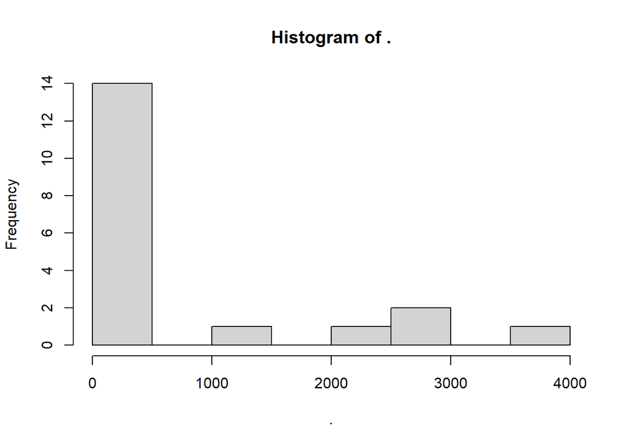

```r
# Quick histograms of time_proc for CABG and PCI
## CABG
apdc_subset_proc %>%
  filter(cabg == 1) %>%
  pull(time_proc) %>%
  hist()
```

**Show R code**

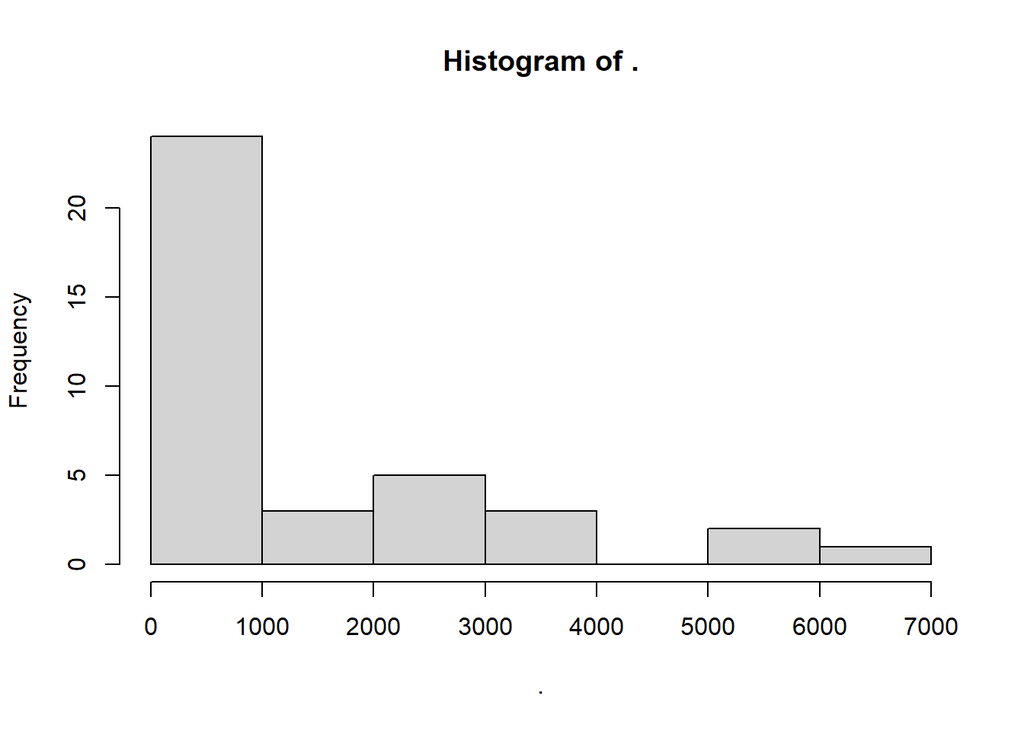

```r
## PCI
apdc_subset_proc %>%
  filter(pci == 1) %>%
  pull(time_proc) %>%
  hist()
```

**Show R code**

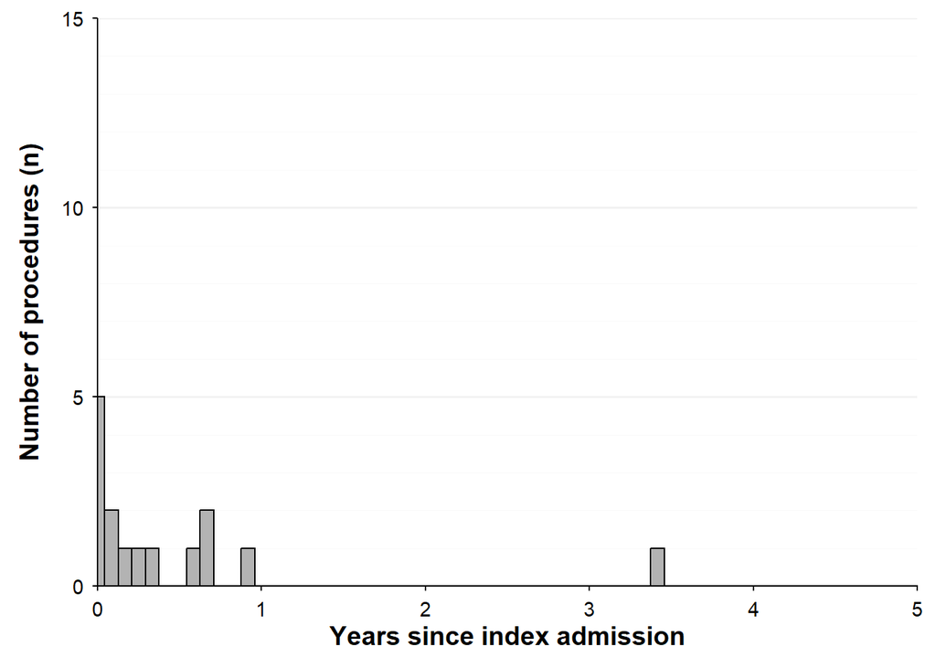

```r
## Nicer looking histograms
## CABG
ggplot(data = apdc_subset_proc %>% filter(cabg == 1), mapping = aes(x = time_proc)) +
  geom_histogram(binwidth = 365.25/12, colour = "black", fill = "grey70") +
  xlab("Years since index admission") +
  ylab("Number of procedures (n)") +
  coord_cartesian(xlim = c(0, (365.25 * 5)),
                  ylim = c(0, 15)) +
  scale_x_continuous(breaks = seq(0, (365.25 * 5), 365.25),
                     labels = seq(0, 5, 1),
                     minor_breaks = seq(0, (365.25 * 5), 365.25/12),
                     expand = c(0, 0)) +
  scale_y_continuous(breaks = seq(0, 15, 5),
                     labels = scales::label_comma(),
                     minor_breaks = seq(0, 15, 1),
                     expand = c(0, 0)) +
  theme_minimal() +
  theme(axis.text = element_text(colour = "black", size = 11),
        axis.title.y = element_text(colour = "black", size = 14, face = "bold",
                                    margin = margin(r = 10)),
        axis.title.x = element_text(colour = "black", size = 14, face = "bold"),
        axis.line = element_line(colour = "black"),
        axis.ticks = element_line(colour = "black"),
        legend.position = "none",
        panel.grid.major.y = element_line(colour = "grey95", linewidth = 0.7),
        panel.grid.minor.y = element_line(colour = "grey98", linewidth = 0.2),
        panel.grid.major.x = element_blank(),
        panel.grid.minor.x = element_blank(),
        panel.border = element_blank(),
        plot.margin = margin(t = 10, b = 10, l = 10, r = 10))
```

**Show R code**

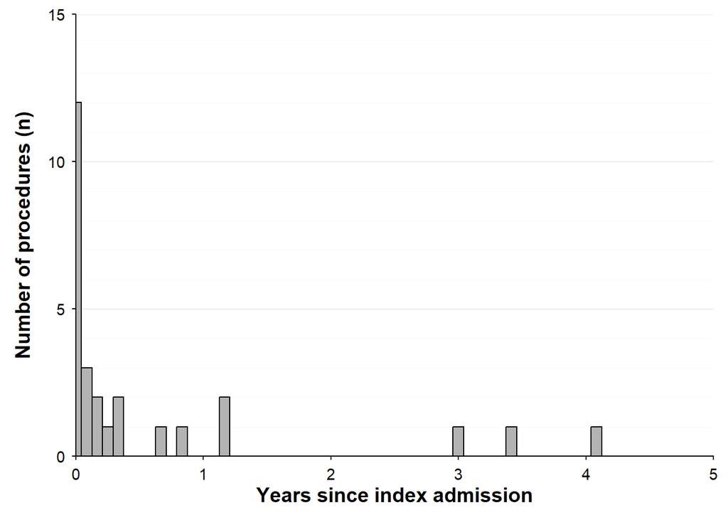

```r
## PCI
ggplot(data = apdc_subset_proc %>% filter(pci == 1), mapping = aes(x = time_proc)) +
  geom_histogram(binwidth = 365.25/12, colour = "black", fill = "grey70") +
  xlab("Years since index admission") +
  ylab("Number of procedures (n)") +
  coord_cartesian(xlim = c(0, (365.25 * 5)),
                  ylim = c(0, 15)) +
  scale_x_continuous(breaks = seq(0, (365.25 * 5), 365.25),
                     labels = seq(0, 5, 1),
                     minor_breaks = seq(0, (365.25 * 5), 365.25/12),
                     expand = c(0, 0)) +
  scale_y_continuous(breaks = seq(0, 15, 5),
                     labels = scales::label_comma(),
                     minor_breaks = seq(0, 15, 1),
                     expand = c(0, 0)) +
  theme_minimal() +
  theme(axis.text = element_text(colour = "black", size = 11),
        axis.title.y = element_text(colour = "black", size = 14, face = "bold",
                                    margin = margin(r = 10)),
        axis.title.x = element_text(colour = "black", size = 14, face = "bold"),
        axis.line = element_line(colour = "black"),
        axis.ticks = element_line(colour = "black"),
        legend.position = "none",
        panel.grid.major.y = element_line(colour = "grey95", linewidth = 0.7),
        panel.grid.minor.y = element_line(colour = "grey98", linewidth = 0.2),
        panel.grid.major.x = element_blank(),
        panel.grid.minor.x = element_blank(),
        panel.border = element_blank(),
        plot.margin = margin(t = 10, b = 10, l = 10, r = 10))
```

Both procedures tend to occur very close in time to the index hospital admission, with most occurring usually within the following few months.

4. Reduce the dataset **apdc_subset_proc** to one observation per ppn, ensuring you obtain data on the CABG or PCI performed in closest date proximity to the index hospital admission (i.e. the observation with the lowest absolute time in *time_proc*). Merge the flag and time for CABG and PCI into the **analysis_data_v2**.

**Show R code**

```r
#CABG variables - taking the minimum time obs only
cabg <- apdc_subset_proc %>%
  filter(cabg == 1) %>%
  select(ppn, cabg, time_proc_cabg = time_proc) %>%
  arrange(ppn, time_proc_cabg) %>%
  group_by(ppn) %>%
  slice(1) %>%
  ungroup

#PCI variables - taking the minimum time obs only
pci <- apdc_subset_proc %>%
  filter(pci == 1) %>%
  select(ppn, pci, time_proc_pci = time_proc) %>%
  arrange(ppn, time_proc_pci) %>%
  group_by(ppn) %>%
  slice(1) %>%
  ungroup

#Merge into analysis data
analysis_data_v2 <- analysis_data_v2 %>%
  left_join(cabg, by="ppn") %>%
  left_join(pci, by="ppn") %>%
  mutate(cabg = coalesce(cabg, 0),
         pci = coalesce(pci, 0))
```

5. How many patients had a CABG or PCI or both?

**Show R code**

```r
# Summary of patients with CABG and PCI
analysis_data_v2 %>%
  mutate(
    cabg = factor(cabg, levels = c(0,1), labels = c("No CABG", "CABG")),
    pci  = factor(pci,  levels = c(0,1), labels = c("No PCI",  "PCI"))
  ) %>%
  select(ppn, cabg, pci) %>%
  distinct() %>%
  tabyl(cabg, pci) %>%
  adorn_totals(c("row", "col")) %>%
  rename(` `= cabg)
```

```
         No PCI PCI Total
 No CABG    172  24   196
    CABG     15   4    19
   Total    187  28   215
```

**Show R code**

```r
# Add cell percentages to table
analysis_data_v2 %>%
  mutate(
    cabg = factor(cabg, levels = c(0,1), labels = c("No CABG", "CABG")),
    pci  = factor(pci,  levels = c(0,1), labels = c("No PCI",  "PCI"))
  ) %>%
  select(ppn, cabg, pci) %>%
  distinct() %>%
  tabyl(cabg, pci) %>%
  adorn_totals(c("row", "col")) %>%
  adorn_percentages(denominator = "all") %>%
  adorn_pct_formatting(digits = 1) %>%
  adorn_ns(position = "front") %>%
  rename(` `= cabg)
```

```
              No PCI        PCI        Total
 No CABG 172 (80.0%) 24 (11.2%) 196  (91.2%)
    CABG  15  (7.0%)  4  (1.9%)  19   (8.8%)
   Total 187 (87.0%) 28 (13.0%) 215 (100.0%)
```

There were 19 patients with CABG and 28 patients with PCI. A total of 4 patients had both CABG and PCI.

6. What proportion of patients had a CABG procedure prior to or within 30 days after the index hospital admission? Similarly, what proportion of patients had a PCI procedure prior to or within 30 days after the index hospital admission?

**Show R code**

```r
# Table
analysis_data_v2 %>%
  mutate(
    time30_cabg = factor(if_else(time_proc_cabg<=30, 1L, 0L), levels = c(0,1), labels = c("CABG>30 days", "CABG<=30 days")),
    time30_pci  = factor(if_else(time_proc_pci<=30, 1L, 0L),  levels = c(0,1), labels = c("PCI>30 days", "PCI<=30 days"))
  ) %>%
  filter(cabg==1 | pci==1) %>%
  select(ppn, time30_cabg, time30_pci) %>%
  distinct() %>%
  tabyl(time30_cabg, time30_pci) %>%
  adorn_totals(c("row", "col")) %>%
  rename(` `= time30_cabg)
```

```
               PCI>30 days PCI<=30 days NA_ Total
  CABG>30 days           2            1   9    12
 CABG<=30 days           1            0   6     7
          <NA>          11           13   0    24
         Total          14           14  15    43
```

Of the 19 patients with CABG, 12 (63%) had the procedure more than 30 days and 7 (37%) within 30 days of the index hospital admission. Of the 28 patients with PCI, 14 (50%) had the procedure more than 30 days and 14 (50%) had within 30 days of the index hospital admission. Of the 4 patients who had both CABG and PCI, 2 (50%) had both procedures more than 30 days, 1 (25%) had CABG more than 30 days and PCI within 30 days, 1 (25%) had CABG within 30 days and PCI more than 30 days, and none had both CABG and PCI within 30 days.

**NoteNote**

It is difficult to generate table with percentages in these circumstances as the denominator varies between these three groups (any CABG, any PCI and both CABG and PCI).

7. Where procedures were conducted more than 30 days, set the *cabg* or *pci* to 0.

**Show R code**

```r
# Reset cabg or pci to 0 if more than 30 days
analysis_data_v2 <- analysis_data_v2 %>%
  mutate(cabg = if_else(time_proc_cabg>30, 0L, cabg),
         pci = if_else(time_proc_pci>30, 0L, pci))

#Adjust to make sure NA is 0
analysis_data_v2 <- analysis_data_v2 %>%
  mutate(cabg = coalesce(cabg, 0),
         pci = coalesce(pci, 0))
```

## SURVIVAL ANALYSIS

## Question 6

Using **analysis_data_v2**, complete the following for each of the variables created above (i.e. *agecat, sex, ra_2016, seifa_irsd_decile, cogrp, diabcode, cabg* and *pci*):

1. Create a KM survival plot for time to death, showing a survival curve for each group of the categorical variables. Ensure all categorical variables are appropriate formatted with labels prior to plotting the survival curves.

**Show R code**

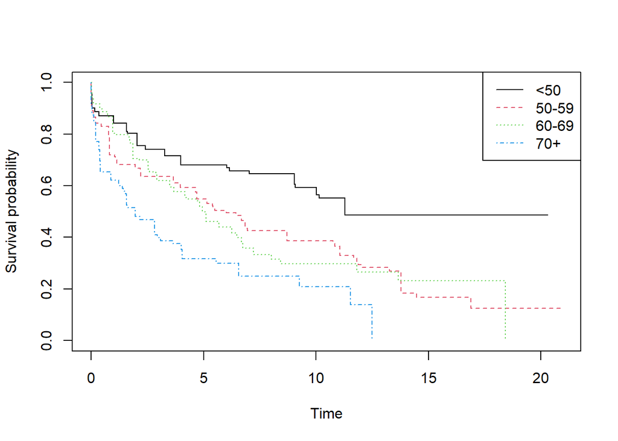

```r
## Format categorical variables
analysis_data_v2 <- analysis_data_v2 %>%
  mutate(ra_2016 = factor(ra_2016,
                          levels=c("Major Cities of Australia", "Inner Regional Australia", "Outer Regional Australia", "Remote Australia", "Very Remote Australia")),
         seifa_irsd_decile = factor(seifa_irsd_decile, levels=1:10),
         diabcode = factor(diabcode, levels=0:1),
         cabg=factor(cabg, levels=0:1),
         pci=factor(pci, levels=0:1))

# Quick KM plots
## agecat
survfit_agecat <- survfit(data = analysis_data_v2,
                        formula = Surv(time = survtime, event = status) ~ agecat)

plot(survfit_agecat,
     col = 1:4,
     lty = 1:4,
     xlab = "Time",
     ylab = "Survival probability")
legend("topright",
       legend = levels(analysis_data_v2$agecat),
       col = 1:4,
       lty = 1:4)
```

**Show R code**

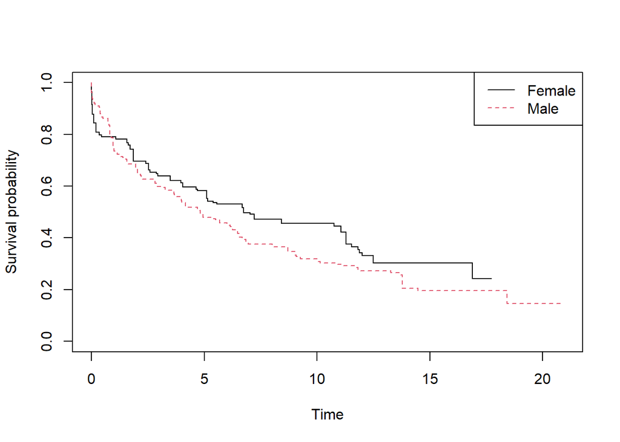

```r
## sex
survfit_sex <- survfit(data = analysis_data_v2,
                        formula = Surv(time = survtime, event = status) ~ sex)

plot(survfit_sex,
     col = 1:2,
     lty = 1:2,
     xlab = "Time",
     ylab = "Survival probability")
legend("topright",
       legend = levels(analysis_data_v2$sex),
       col = 1:2,
       lty = 1:2)
```

**Show R code**

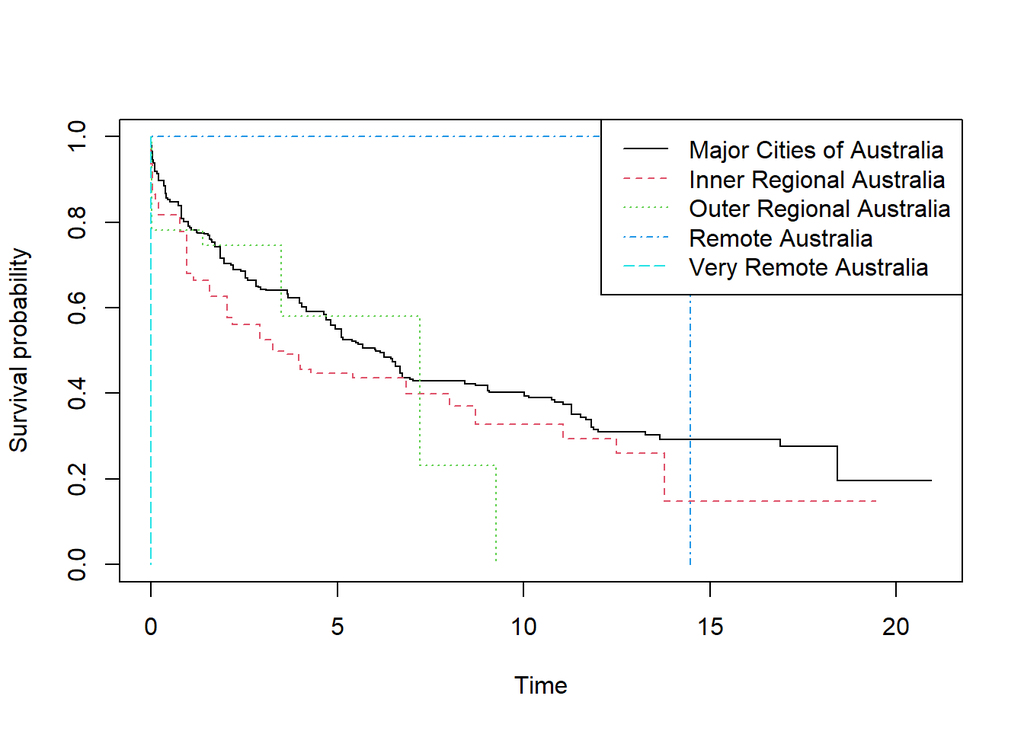

```r
## remoteness
survfit_ra <- survfit(data = analysis_data_v2,
                        formula = Surv(time = survtime, event = status) ~ ra_2016)

plot(survfit_ra,
     col = 1:5,
     lty = 1:5,
     xlab = "Time",
     ylab = "Survival probability")
legend("topright",
       legend = levels(analysis_data_v2$ra_2016),
       col = 1:5,
       lty = 1:5)
```

**Show R code**

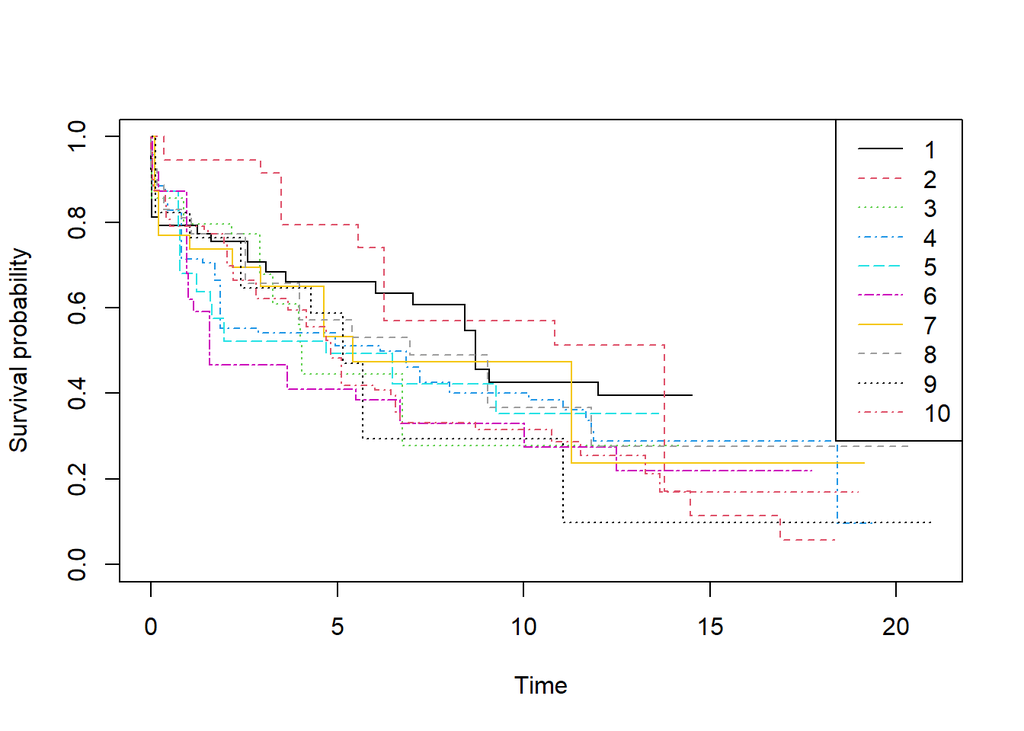

```r
## ses
survfit_ses <- survfit(data = analysis_data_v2,
                        formula = Surv(time = survtime, event = status) ~ seifa_irsd_decile)

plot(survfit_ses,
     col = 1:10,
     lty = 1:10,
     xlab = "Time",
     ylab = "Survival probability")
legend("topright",
       legend = levels(analysis_data_v2$seifa_irsd_decile),
       col = 1:10,
       lty = 1:10)
```

**Show R code**

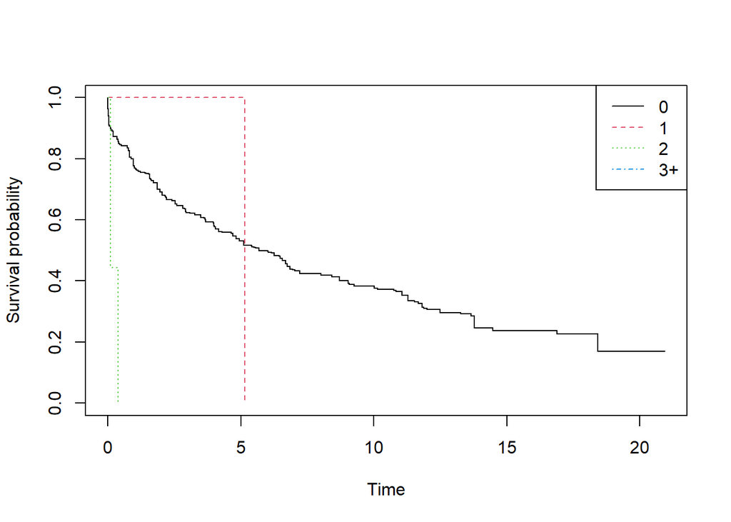

```r
## comorbid
survfit_cci <- survfit(data = analysis_data_v2,
                        formula = Surv(time = survtime, event = status) ~ cogrp)

plot(survfit_cci,
     col = 1:4,
     lty = 1:4,
     xlab = "Time",
     ylab = "Survival probability")
legend("topright",
       legend = levels(analysis_data_v2$cogrp),
       col = 1:4,
       lty = 1:4)
```

**Show R code**

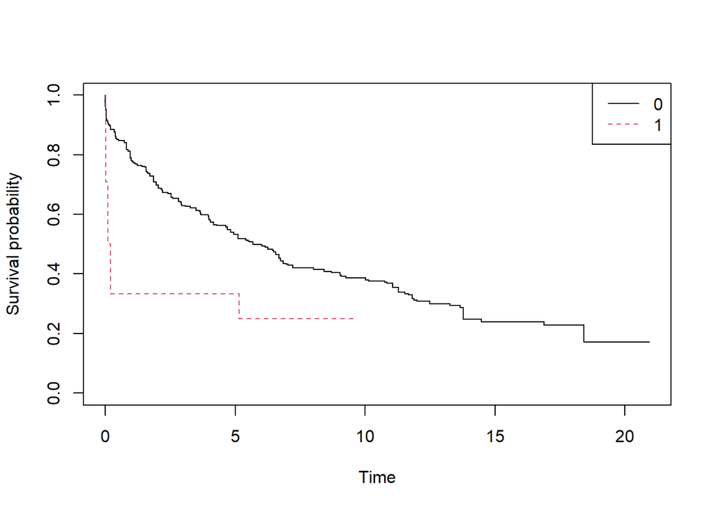

```r
## diabcode
survfit_diab <- survfit(data = analysis_data_v2,
                        formula = Surv(time = survtime, event = status) ~ diabcode)

plot(survfit_diab,
     col = 1:2,
     lty = 1:2,
     xlab = "Time",
     ylab = "Survival probability")
legend("topright",
       legend = levels(analysis_data_v2$diabcode),
       col = 1:2,
       lty = 1:2)
```

**Show R code**

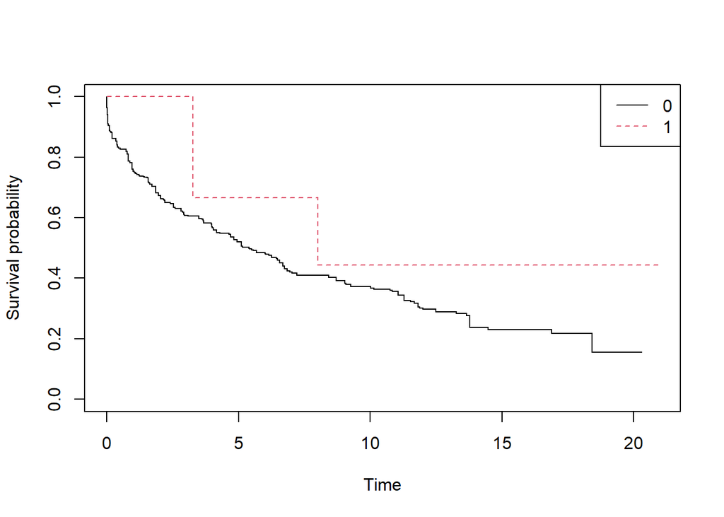

```r
## cabg
survfit_cabg <- survfit(data = analysis_data_v2,
                        formula = Surv(time = survtime, event = status) ~ cabg)

plot(survfit_cabg,
     col = 1:2,
     lty = 1:2,
     xlab = "Time",
     ylab = "Survival probability")
legend("topright",
       legend = levels(analysis_data_v2$cabg),
       col = 1:2,
       lty = 1:2)
```

**Show R code**

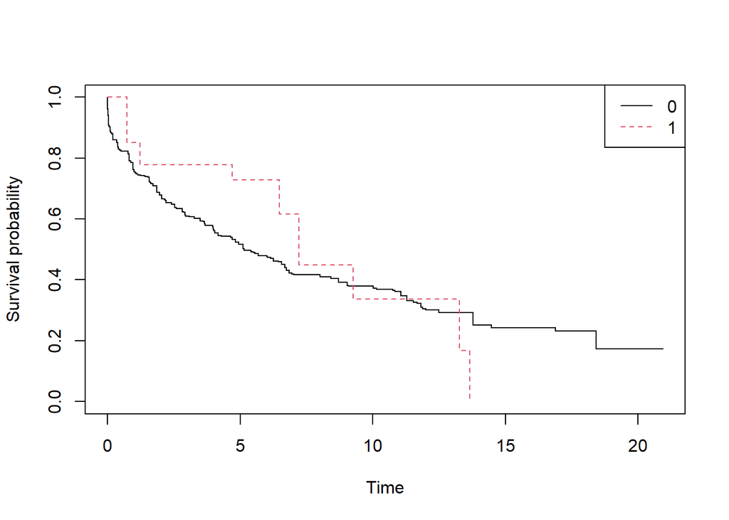

```r
## pci
survfit_pci <- survfit(data = analysis_data_v2,
                        formula = Surv(time = survtime, event = status) ~ pci)

plot(survfit_pci,
     col = 1:2,
     lty = 1:2,
     xlab = "Time",
     ylab = "Survival probability")
legend("topright",
       legend = levels(analysis_data_v2$cabg),
       col = 1:2,
       lty = 1:2)
```

2. Conduct a log-rank test to calculate a p-value to determine if there is evidence of a difference in survival between groups of that variable.

**Show R code**

```r
# Quick log rank tests
## agecat
survdiff(data = analysis_data_v2,
         formula = Surv(time = survtime, event = status) ~ agecat)
```

```
Call:
survdiff(formula = Surv(time = survtime, event = status) ~ agecat,
    data = analysis_data_v2)

               N Observed Expected (O-E)^2/E (O-E)^2/V
agecat=<50   141       56     99.9    19.279    27.529
agecat=50-59 164      104     98.3     0.325     0.458
agecat=60-69 205      124    117.7     0.336     0.513
agecat=70+    96       72     40.1    25.450    29.375

 Chisq= 46.9  on 3 degrees of freedom, p= 4e-10
```

**Show R code**

```r
## sex
survdiff(data = analysis_data_v2,
         formula = Surv(time = survtime, event = status) ~ sex)
```

```
Call:
survdiff(formula = Surv(time = survtime, event = status) ~ sex,
    data = analysis_data_v2)

             N Observed Expected (O-E)^2/E (O-E)^2/V
sex=Female 262      138      156      1.97      3.58
sex=Male   344      218      200      1.53      3.58

 Chisq= 3.6  on 1 degrees of freedom, p= 0.06
```

**Show R code**

```r
## remoteness
survdiff(data = analysis_data_v2,
         formula = Surv(time = survtime, event = status) ~ ra_2016)
```

```
Call:
survdiff(formula = Surv(time = survtime, event = status) ~ ra_2016,
    data = analysis_data_v2)

                                    N Observed Expected (O-E)^2/E (O-E)^2/V
ra_2016=Major Cities of Australia 427      243 265.0799     1.839     7.322
ra_2016=Inner Regional Australia  142       91  74.8141     3.502     4.508
ra_2016=Outer Regional Australia   32       17  14.5858     0.400     0.424
ra_2016=Remote Australia            1        1   1.4344     0.132     0.135
ra_2016=Very Remote Australia       4        4   0.0858   178.547   183.371

 Chisq= 189  on 4 degrees of freedom, p= <2e-16
```

**Show R code**

```r
## ses
survdiff(data = analysis_data_v2,
         formula = Surv(time = survtime, event = status) ~ seifa_irsd_decile)
```

```
Call:
survdiff(formula = Surv(time = survtime, event = status) ~ seifa_irsd_decile,
    data = analysis_data_v2)

n=598, 8 observations deleted due to missingness.

                       N Observed Expected (O-E)^2/E (O-E)^2/V
seifa_irsd_decile=1   53       26     36.3    2.9455    3.3536
seifa_irsd_decile=2   38       20     28.0    2.2965    2.5534
seifa_irsd_decile=3   49       28     25.6    0.2283    0.2512
seifa_irsd_decile=4  105       66     67.3    0.0260    0.0328
seifa_irsd_decile=5   47       27     24.3    0.3024    0.3295
seifa_irsd_decile=6   78       47     37.1    2.6232    3.0075
seifa_irsd_decile=7   39       19     20.4    0.0907    0.0985
seifa_irsd_decile=8   53       29     32.5    0.3859    0.4317
seifa_irsd_decile=9   17       14     11.5    0.5660    0.5949
seifa_irsd_decile=10 119       77     69.9    0.7108    0.9035

 Chisq= 10.4  on 9 degrees of freedom, p= 0.3
```

**Show R code**

```r
## comorbid
survdiff(data = analysis_data_v2,
         formula = Surv(time = survtime, event = status) ~ cogrp)
```

```
Call:
survdiff(formula = Surv(time = survtime, event = status) ~ cogrp,
    data = analysis_data_v2)

           N Observed Expected (O-E)^2/E (O-E)^2/V
cogrp=0  593      345   352.77  1.71e-01  1.92e+01
cogrp=1    4        2     2.03  3.42e-04  3.48e-04
cogrp=3+   9        9     1.20  5.07e+01  5.20e+01

 Chisq= 52  on 2 degrees of freedom, p= 5e-12
```

**Show R code**

```r
## diabcode
survdiff(data = analysis_data_v2,
         formula = Surv(time = survtime, event = status) ~ diabcode)
```

```
Call:
survdiff(formula = Surv(time = survtime, event = status) ~ diabcode,
    data = analysis_data_v2)

n=591, 15 observations deleted due to missingness.

             N Observed Expected (O-E)^2/E (O-E)^2/V
diabcode=0 567      330   339.38     0.259      10.6
diabcode=1  24       18     8.62    10.217      10.6

 Chisq= 10.6  on 1 degrees of freedom, p= 0.001
```

**Show R code**

```r
## cabg procedure
survdiff(data = analysis_data_v2,
         formula = Surv(time = survtime, event = status) ~ cabg)
```

```
Call:
survdiff(formula = Surv(time = survtime, event = status) ~ cabg,
    data = analysis_data_v2)

         N Observed Expected (O-E)^2/E (O-E)^2/V
cabg=0 588      351    345.4    0.0902      3.09
cabg=1  18        5     10.6    2.9439      3.09

 Chisq= 3.1  on 1 degrees of freedom, p= 0.08
```

**Show R code**

```r
## pci procedure
survdiff(data = analysis_data_v2,
         formula = Surv(time = survtime, event = status) ~ pci)
```

```
Call:
survdiff(formula = Surv(time = survtime, event = status) ~ pci,
    data = analysis_data_v2)

        N Observed Expected (O-E)^2/E (O-E)^2/V
pci=0 579      340    338.2   0.00969     0.196
pci=1  27       16     17.8   0.18394     0.196

 Chisq= 0.2  on 1 degrees of freedom, p= 0.7
```

**TipOPTIONAL**

Instead of copy-pasting the same code and changing a variable name each time, we can create a function that produces the plot we want. See below R coding and example.

**Show R code**

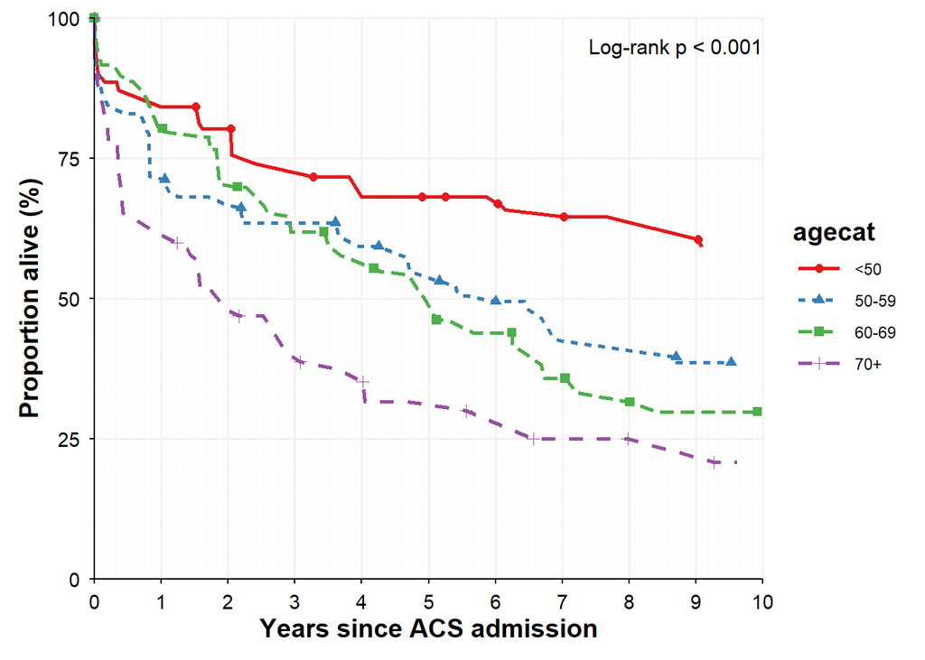

```r
# Nicer plots -  if interested
kmplot <- function(variable) {
  ## If variable is not already a factor, convert it to one
  data <- analysis_data_v2
  data[variable] <- as.factor(data %>% pull(all_of(variable)))

  ## Calculate p-value using log-rank test
  pval <- survdiff(data = data,
                   formula = as.formula(paste0("Surv(time = survtime, event = status) ~ ", variable)))$pvalue

  ## Format p-value
  pval_label <- case_when(
    pval >= 0.9 ~ "p = 0.9",
    pval >= 0.095 ~ paste0("p = ", round(pval, 1)),
    pval >= 0.0095 ~ paste0("p = ", round(pval, 2)),
    pval > 0.001 ~ paste0("p = ", round(pval, 3)),
    TRUE ~ "p < 0.001")

  ## Create survfit object for KM plot
  survfit <- survfit(data = data,
                     as.formula(paste0("Surv(time = survtime, event = status) ~ ", variable)))

  ## Create vector of factor levels
  factor_levels <- data %>% pull(all_of(variable)) %>% levels()

  ## Create dataset for plotting
  plotdata <- tidy(survfit) %>%
    select(strata, time, estimate) %>%
    mutate(strata = factor(
      str_replace(strata, ".*=", ""),
      levels = factor_levels)) %>%
    bind_rows(tibble(strata = factor(factor_levels, levels = factor_levels),
                     time = 0,
                     estimate = 1), .) %>%
    arrange(strata, time, estimate) %>%
    filter(time<=10)

  ## Create KM plot
  plot <- ggplot(data = plotdata, mapping = aes(x = time, y = estimate)) +
    geom_line(aes(colour = strata, linetype = strata), linewidth = 1) +
    geom_point(data = plotdata %>%
                 mutate(year = floor(time)) %>%
                 group_by(strata, year) %>%
                 slice(1) %>%
                 ungroup(),
               aes(colour = strata, shape = strata),
               size = 2) +
    annotate(geom = "text", x = 10, y = 0.95, label = paste0("Log-rank ", pval_label),
             size = 4, colour = "black", hjust = 1) +
    xlab("Years since ACS admission") +
    ylab("Proportion alive (%)") +
    labs(colour = variable, linetype = variable, shape = variable) +
    coord_cartesian(xlim = c(0, 10),
                    ylim = c(0, 1),
                    clip = "off") +
    scale_x_continuous(breaks = 0:10,
                       minor_breaks = seq(0, 10, 1/12),
                       expand = c(0, 0)) +
    scale_y_continuous(breaks = seq(0, 1, 0.25),
                       labels = seq(0, 100, 25),
                       minor_breaks = seq(0, 1, 0.05),
                       expand = c(0, 0)) +
    scale_color_brewer(palette = "Set1") +
    theme_minimal() +
    theme(axis.text = element_text(colour = "black", size = 11),
          axis.title = element_text(colour = "black", size = 14, face = "bold"),
          axis.line = element_line(colour = "black"),
          axis.ticks = element_line(colour = "black"),
          legend.position = "right",
          legend.key.width = unit(1, "cm"),
          legend.title = element_text(face = "bold", size = 14),
          panel.grid.major = element_line(colour = "grey95", linewidth = 0.7),
          panel.grid.minor = element_line(colour = "grey98", linewidth = 0.2),
          panel.border = element_blank(),
          plot.margin = margin(t = 10, b = 10, l = 10, r = 10))

  ## Return KM plot as output
  return(plot)
}

## Now run the function to create a KM plot for each variable
kmplot("agecat")
```

**Show R code**

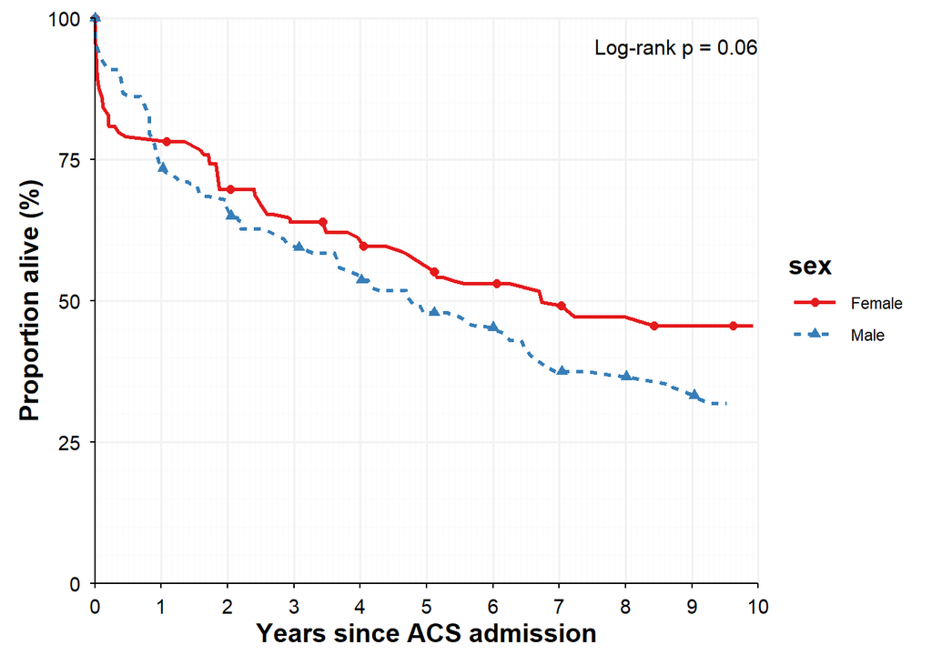

```r
kmplot("sex")
```

**Show R code**

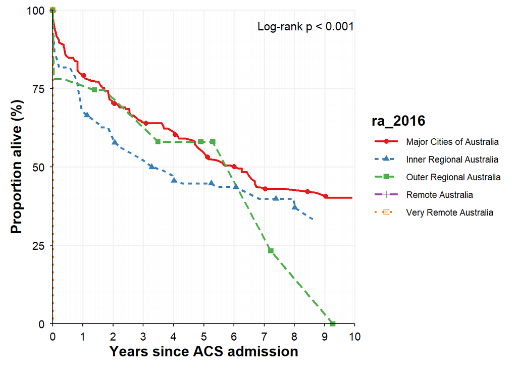

```r
kmplot("ra_2016")
```

**Show R code**

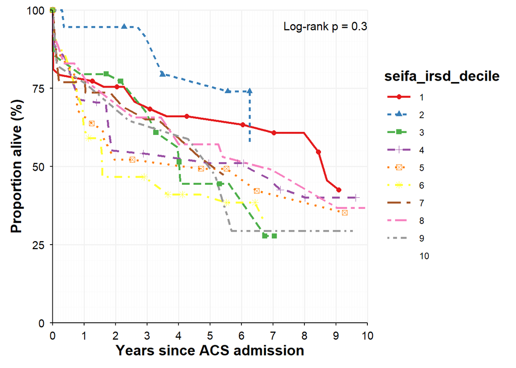

```r
kmplot("seifa_irsd_decile")
```

**Show R code**

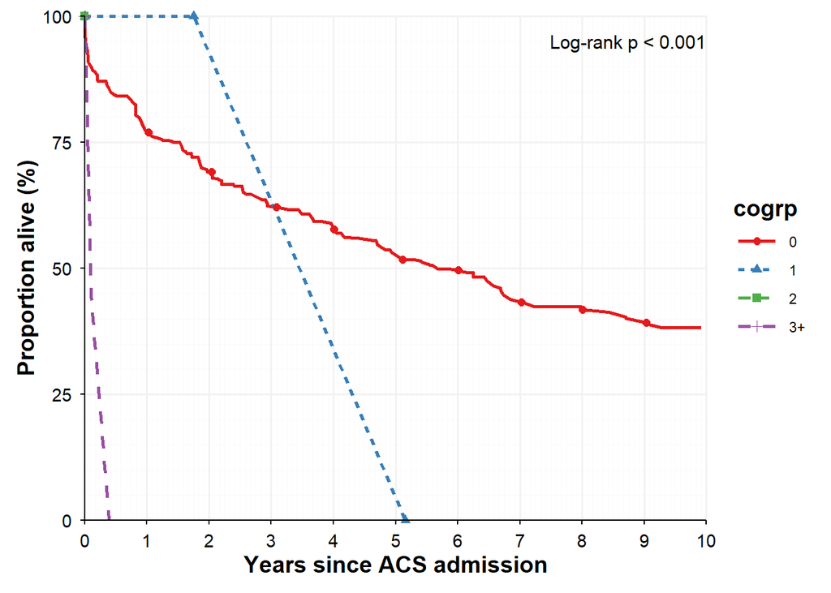

```r
kmplot("cogrp")
```

**Show R code**

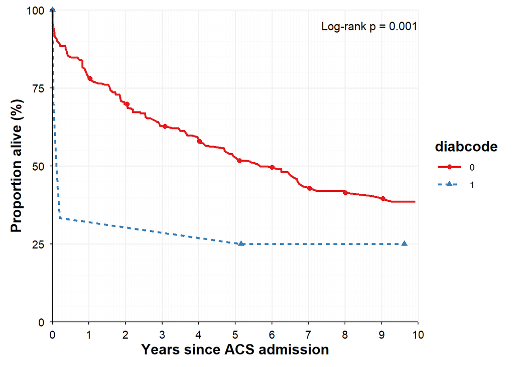

```r
kmplot("diabcode")
```

**Show R code**

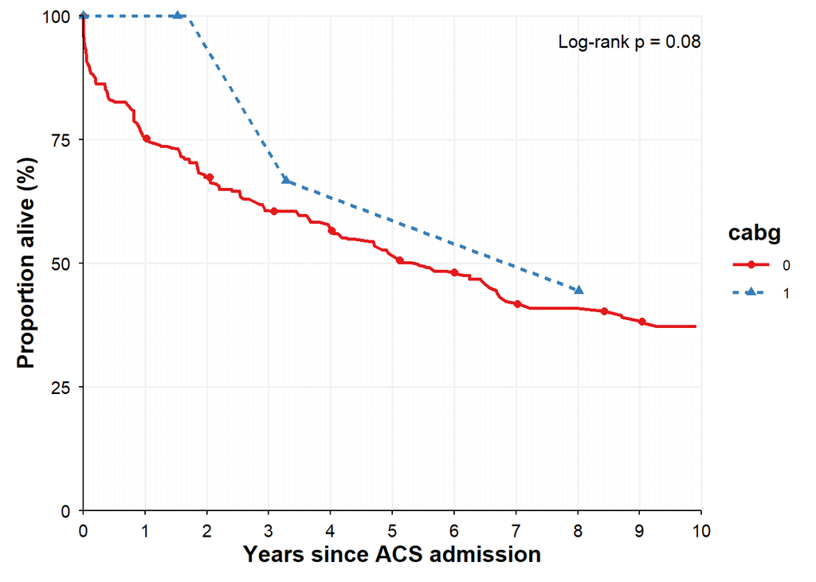

```r
kmplot("cabg")
```

**Show R code**

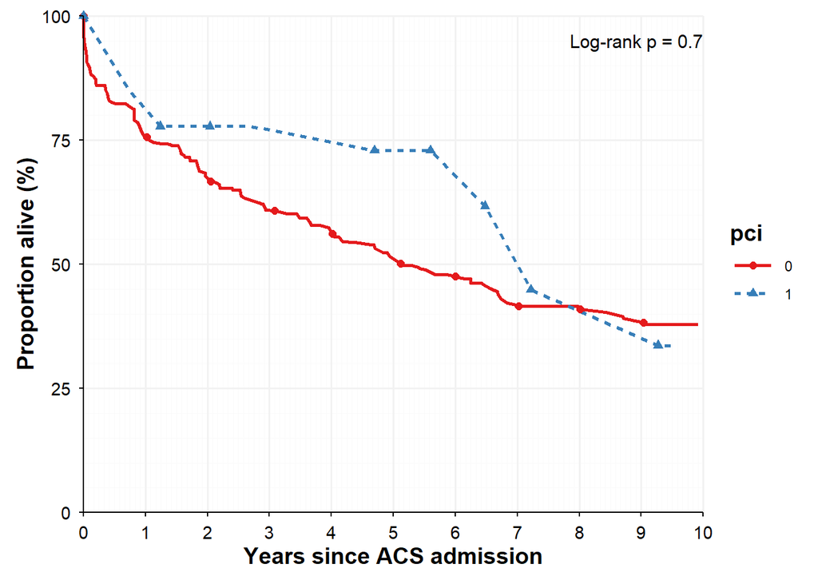

```r
kmplot("pci")
```

3. What are some important considerations applicable for this analysis that you might change?
- Some variables have too many categories with too few observations (e.g. *seifa_irsd_decile, ra_2016*). We should consider reducing the number of categories.
- KM plots for some variables (e.g. *sex*) are concerning as the survival probability lines cross over between categories, suggesting non-proportionality for Cox modelling.

## Question 7

OPTIONAL: Fit a Cox proportional hazards model (*coxph()*) including one or multiple of the variables created above: *agecat, sex, ra_2016, seifa_irsd_decile, cogrp, diabcode, cabg* and *pci*. Interpret the results.

**Show R code**

```r
# Univariate Cox model
## agecat
cox_agecat <- coxph(data=analysis_data_v2,
                    Surv(time = survtime, event = status) ~ agecat)
summary(cox_agecat)
```

```
Call:
coxph(formula = Surv(time = survtime, event = status) ~ agecat,
    data = analysis_data_v2)

  n= 606, number of events= 356

              coef exp(coef) se(coef)     z Pr(>|z|)
agecat50-59 0.6453    1.9065   0.1659 3.889 0.000101 ***
agecat60-69 0.6548    1.9248   0.1621 4.039 5.36e-05 ***
agecat70+   1.2005    3.3217   0.1807 6.642 3.10e-11 ***
---
Signif. codes:  0 '***' 0.001 '**' 0.01 '*' 0.05 '.' 0.1 ' ' 1

            exp(coef) exp(-coef) lower .95 upper .95
agecat50-59     1.907     0.5245     1.377     2.639
agecat60-69     1.925     0.5195     1.401     2.645
agecat70+       3.322     0.3010     2.331     4.734

Concordance= 0.58  (se = 0.017 )
Likelihood ratio test= 45.68  on 3 df,   p=7e-10
Wald test            = 44.14  on 3 df,   p=1e-09
Score (logrank) test = 46.82  on 3 df,   p=4e-10
```

**Show R code**

```r
## pci
cox_pci <- coxph(data=analysis_data_v2,
                    Surv(time = survtime, event = status) ~ pci)
summary(cox_pci)
```

```
Call:
coxph(formula = Surv(time = survtime, event = status) ~ pci,
    data = analysis_data_v2)

  n= 606, number of events= 356

        coef exp(coef) se(coef)     z Pr(>|z|)
pci1 -0.1152    0.8912   0.2562 -0.45    0.653

     exp(coef) exp(-coef) lower .95 upper .95
pci1    0.8912      1.122    0.5394     1.473

Concordance= 0.509  (se = 0.005 )
Likelihood ratio test= 0.21  on 1 df,   p=0.6
Wald test            = 0.2  on 1 df,   p=0.7
Score (logrank) test = 0.2  on 1 df,   p=0.7
```

*agecat* is significantly associated with survival (p<0.001). Patients aged 50-59 years were 1.91 times (HR: 1.91, 95%CIL 1.38, 2.64) more likely to die compared to patients aged <50 years.

*pci* is not significantly associated with survival (p>0.05).

**Show R code**

```r
# Multivariate Cox model
cox_multi <- coxph(data=analysis_data_v2,
                    Surv(time = survtime, event = status) ~ agecat + pci)
summary(cox_multi)
```

```
Call:
coxph(formula = Surv(time = survtime, event = status) ~ agecat +
    pci, data = analysis_data_v2)

  n= 606, number of events= 356

               coef exp(coef) se(coef)      z Pr(>|z|)
agecat50-59  0.6463    1.9085   0.1660  3.895 9.83e-05 ***
agecat60-69  0.6569    1.9287   0.1621  4.051 5.10e-05 ***
agecat70+    1.2037    3.3325   0.1808  6.657 2.80e-11 ***
pci1        -0.1610    0.8513   0.2564 -0.628     0.53
---
Signif. codes:  0 '***' 0.001 '**' 0.01 '*' 0.05 '.' 0.1 ' ' 1

            exp(coef) exp(-coef) lower .95 upper .95
agecat50-59    1.9085     0.5240    1.3786     2.642
agecat60-69    1.9287     0.5185    1.4036     2.650
agecat70+      3.3325     0.3001    2.3380     4.750
pci1           0.8513     1.1747    0.5151     1.407

Concordance= 0.581  (se = 0.017 )
Likelihood ratio test= 46.09  on 4 df,   p=2e-09
Wald test            = 44.55  on 4 df,   p=5e-09
Score (logrank) test = 47.22  on 4 df,   p=1e-09
```

*pci* remains not significantly associated with survival (p>0.05), after adjusting for age.

**NoteNote**

The power of Cox proportional hazards model is dependent on number of events, in this case, the number of deaths. While the number of deaths is decent in our analysis (deaths = 356), the number of deaths does get further stratified with many categories in a categorical variable. For example, *seifa_irsd_decile* would further reduce power with 10 categories (9 variables) added to the model. This is an important consideration, alongside potential violation of proportional hazards assumptions indicated by KM plots in Question 6.